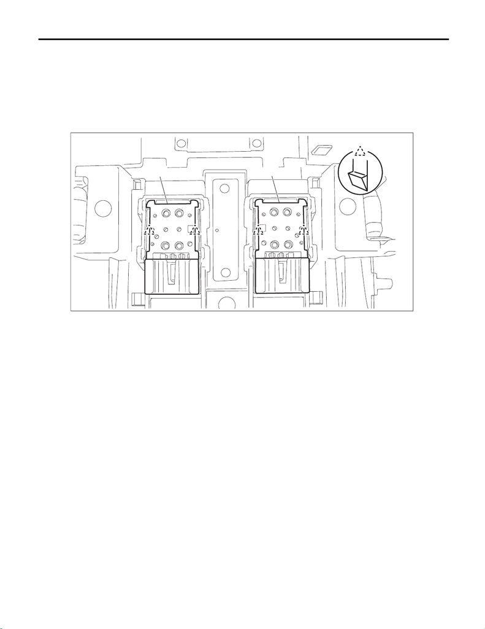

Sunroof Switch

SUNROOF/T-TOP/CONVERTIBLE TOP (SUNROOF)

7. Sunroof Switch

A: REMOVAL

1) Disconnect the ground cable from battery. <Ref. to NT-5, BATTERY, NOTE, Note.>

NOTE:

For models other than STI model, disconnect the ground terminal from battery sensor.

2) Remove the light assembly - map. <Ref. to LI-60, REMOVAL, Spot Map Light.>

3) Release the claws and remove the sunroof switch from the light assembly - map.

B: INSTALLATION

1) Install the sunroof switch.

2) Install the light assembly - map.

3) Connect the battery ground terminal. <Ref. to NT-5, BATTERY, NOTE, Note.>

NOTE:

For models other than STI model, connect the ground terminal to battery sensor.

(1) Sunroof switch (tilt) (2) Sunroof switch (slide)

(1) (2)

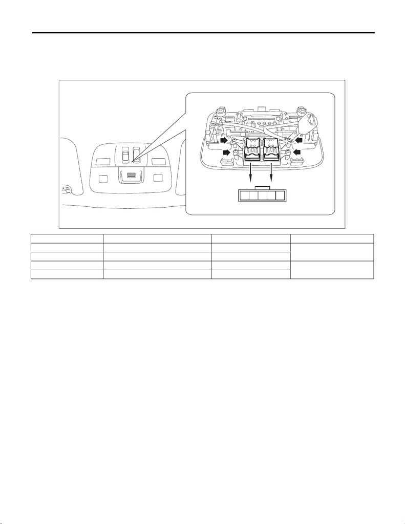

Sunroof Switch

SUNROOF/T-TOP/CONVERTIBLE TOP (SUNROOF)

C: INSPECTION

1) Measure the resistance between connector terminals.

Preparation tool:

Circuit tester

2) Replace the sunroof switch if the inspection result is not within the standard value.

Terminal No. Inspection conditions Standard Connector No.

1 — 3 Open Less than 1 Ω

R128

4 — 3 Close Less than 1 Ω

1 — 3 Tilt up Less than 1 Ω

R187

4 — 3 Tilt down Less than 1 Ω